# Final Project

The Extrapolats

2024-12-09

# Marriage Proposal Dataset Analysis - Code & Technical Analysis

## STEP 1: Loading the Dataset

```r
# Reading the dataset
proposal_df = read.csv("marriage_proposal.csv")
```

```r
# Structure of the dataset
str(proposal_df)
```

```
## 'data.frame':    10000 obs. of  9 variables:
##  $ Height              : int  157 141 143 184 151 151 166 154 163 190 ...
##  $ Age                 : int  23 80 56 18 31 19 66 55 58 19 ...
##  $ Income              : int  9813 9543 43513 26317 6757 18954 19013 46007 39673 49724 ...
##  $ RomanticGestureScore: int  10 0 4 2 7 9 7 7 3 2 ...
##  $ CompatibilityScore  : int  4 9 2 6 0 0 4 3 8 10 ...
##  $ CommunicationScore  : int  10 3 2 9 8 4 3 2 1 8 ...
##  $ DistanceKM          : int  81 14 55 47 81 21 3 41 84 94 ...
##  $ Response            : int  1 1 0 0 1 0 1 1 1 1 ...
##  $ AgeCategory         : chr  "Young" "Senior" "Middle-aged" "Young" ...
```

## STEP 2: Cleaning the dataset

```r
# Check for empty and NA values
empty_values <- sapply(proposal_df, function(x) sum(x == "", na.rm = TRUE))
na_values <- sapply(proposal_df, function(x) sum(is.na(x)))
print("Empty Values in Each Column:")
```

```
## [1] "Empty Values in Each Column:"
```

```r
print(empty_values)
```

```
##               Height                  Age               Income
##                    0                    0                    0
## RomanticGestureScore   CompatibilityScore   CommunicationScore
##                    0                    0                    0
##           DistanceKM             Response          AgeCategory
##                    0                    0                    0
```

```r
print("NA Values in Each Column:")
```

```
## [1] "NA Values in Each Column:"
```

```r
print(na_values)
```

```
##               Height                  Age               Income
##                    0                    0                    0
## RomanticGestureScore   CompatibilityScore   CommunicationScore
##                    0                    0                    0
##           DistanceKM             Response          AgeCategory
##                    0                    0                    0
```

No Null values were identified so we move on to the Factorization of few integer variables.

```r
# Converting required 'int' columns into 'factor'
proposal_df$RomanticGestureScore <- as.factor(proposal_df$RomanticGestureScore)
proposal_df$CompatibilityScore <- as.factor(proposal_df$CompatibilityScore)
proposal_df$CommunicationScore <- as.factor(proposal_df$CommunicationScore)
proposal_df$Response <- as.factor(proposal_df$Response)
```

```r
print("Summary of cleaned data")
```

```
## [1] "Summary of cleaned data"
```

```r
summary(proposal_df)
```

```
##      Height         Age           Income      RomanticGestureScore
##  Min.   :140   Min.   :18.0   Min.   : 5003   5      : 946
##  1st Qu.:155   1st Qu.:35.0   1st Qu.:16090   10     : 946
##  Median :170   Median :54.0   Median :27109   1      : 940
##  Mean   :170   Mean   :53.9   Mean   :27254   6      : 923
##  3rd Qu.:185   3rd Qu.:72.0   3rd Qu.:38435   0      : 920
##  Max.   :200   Max.   :90.0   Max.   :50000   8      : 917
##                                               (Other):4408
##  CompatibilityScore CommunicationScore   DistanceKM    Response
##  3      : 946       3      : 989       Min.   :  1.0   0:2300
##  8      : 934       5      : 987       1st Qu.: 26.0   1:7700
##  9      : 932       0      : 911       Median : 51.0
##  5      : 914       7      : 909       Mean   : 50.7
##  1      : 909       2      : 907       3rd Qu.: 76.0
##  10     : 909       9      : 901       Max.   :100.0
##  (Other):4456       (Other):4396
##  AgeCategory
##  Length:10000
##  Class :character
##  Mode  :character
##
##
##
##
```

## STEP 3: Exploratory Data Analysis

### Loading necessary libraries

```r
# Load necessary libraries
library(ggplot2)
library(dplyr)
library(psych)
library(tidyverse)
library(ggplot2)
library(viridis)
library(RColorBrewer)
library(ggmosaic)

library(gridExtra)
library(caret)
library(pROC)
library(rpart)
library(rpart.plot)
library(randomForest)
```

### Distribution of the Numeric variables

Let’s take a look at descriptive stats of Numeric variables.

```r
# Descriptive Statistics
# Numeric variables
describe(proposal_df %>% select(Age, Height, Income, DistanceKM))
```

```
##            vars     n    mean      sd median trimmed     mad  min   max range
## Age           1 10000    53.9    21.1     54    53.9    26.7   18    90    72
## Height        2 10000   169.8    17.6    170   169.8    22.2  140   200    60
## Income        3 10000 27253.7 13033.2  27109 27207.3 16608.1 5003 50000 44997
## DistanceKM    4 10000    50.7    28.9     51    50.8    37.1    1   100    99
##            skew kurtosis     se
## Age        0.01    -1.22   0.21
## Height     0.00    -1.21   0.18
## Income     0.03    -1.19 130.33
## DistanceKM 0.00    -1.22   0.29
```

Graphical Representations of Integer variables.

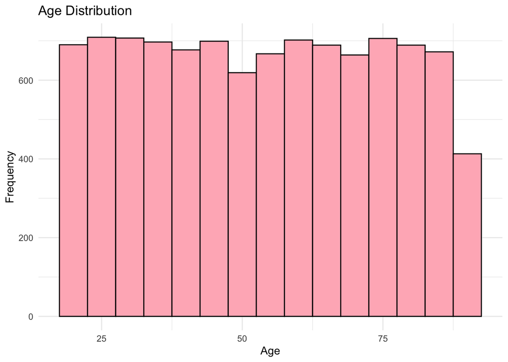

```r
# Histogram of age

ggplot(proposal_df, aes(x = Age, fill = Age)) + geom_histogram(binwidth = 5, fill = "lightpink", color = "black") + labs(title = "Age Distribution", x = "Age", y = "Frequency") + theme_minimal()
```

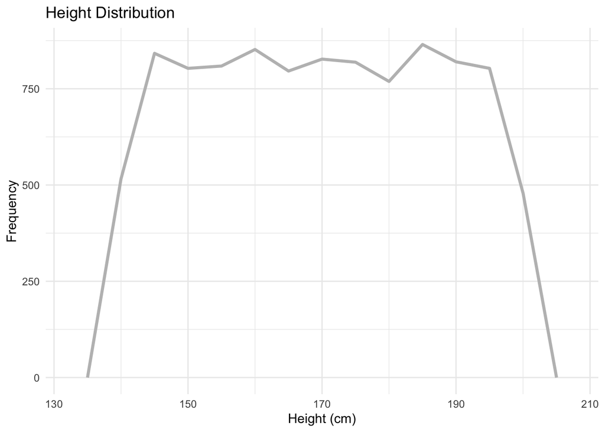

```r
# Frequency polygon for Height
ggplot(proposal_df, aes(x = Height)) +
  geom_freqpoly(binwidth = 5, color = "grey", size = 1.2) +
  labs(title = "Height Distribution", x = "Height (cm)", y = "Frequency") +
  theme_minimal()
```

```r
# We can use this function to check if any outliers were detected in variables.
#proposal_df <- outlierKD2(proposal_df, DistanceKM, rm = TRUE, boxplt = TRUE, histogram = FALSE, qqplt = TRUE)
```

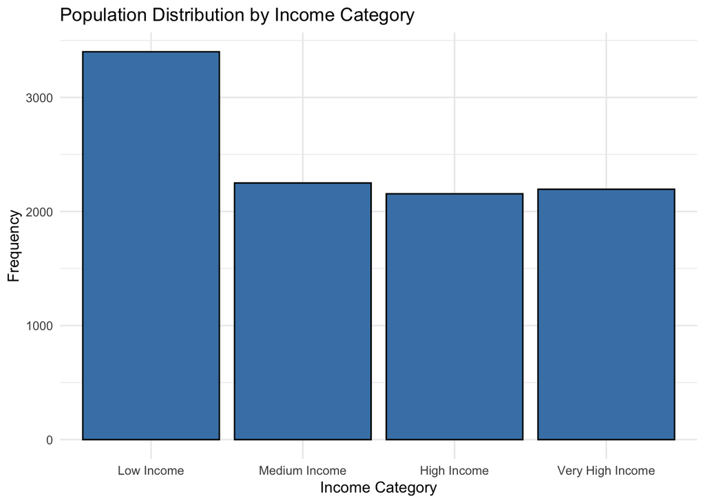

```r
ggplot(proposal_df, aes(x = cut(Income, breaks = c(5000, 20000, 30000, 40000, 50000), labels = c("Low Income", "Medium Income", "High Income", "Very High Income"), include.lowest = TRUE))) + geom_bar(fill = "steelblue", color = "black") + labs(title = "Population Distribution by Income Category", x = "Income Category", y = "Frequency") + theme_minimal()
```

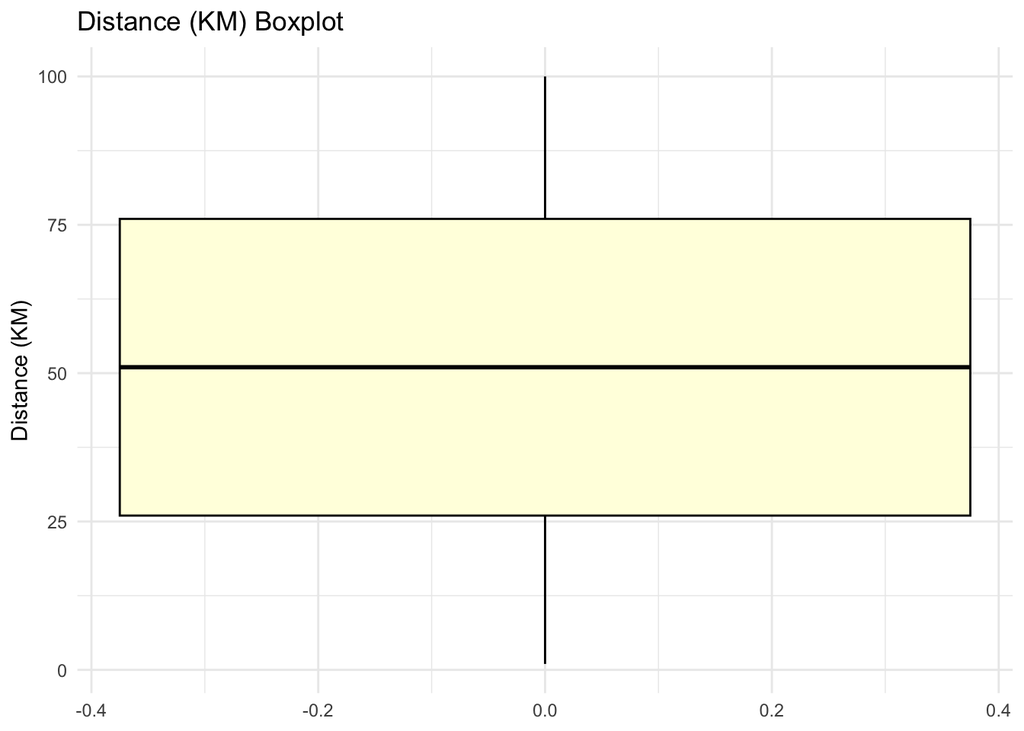

```r
# Boxplot for Distance
ggplot(proposal_df, aes(y = DistanceKM)) + geom_boxplot(fill = "lightyellow", color = "black") + labs(title = "Distance (KM) Boxplot", y = "Distance (KM)") + theme_minimal()
```

Graphical Representations of Factorial variables.

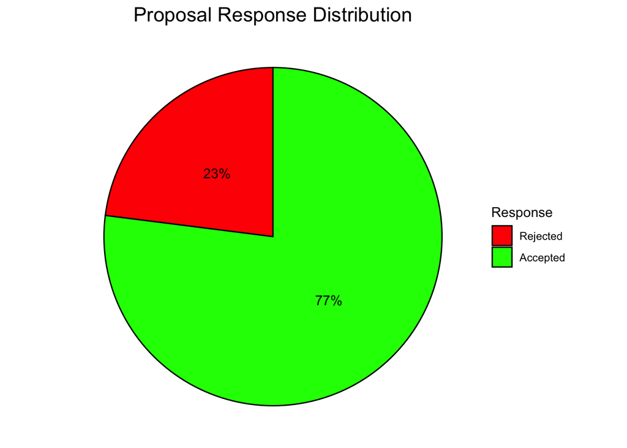

```r
# Pie chart for Response variable
ggplot(proposal_df, aes(x = "", fill = Response)) + geom_bar(width = 1, stat = "count", color = "black") + coord_polar(theta = "y") + geom_text(aes(label = scales::percent(..count../sum(..count..))), position = position_stack(vjust = 0.5), stat = "count") + scale_fill_manual(values = c("0" = "red", "1" = "green"), labels = c("Rejected", "Accepted")) + labs(title = "Proposal Response Distribution", fill = "Response") + theme_void() + theme(plot.title = element_text(hjust = 0.5, size = 16))
```

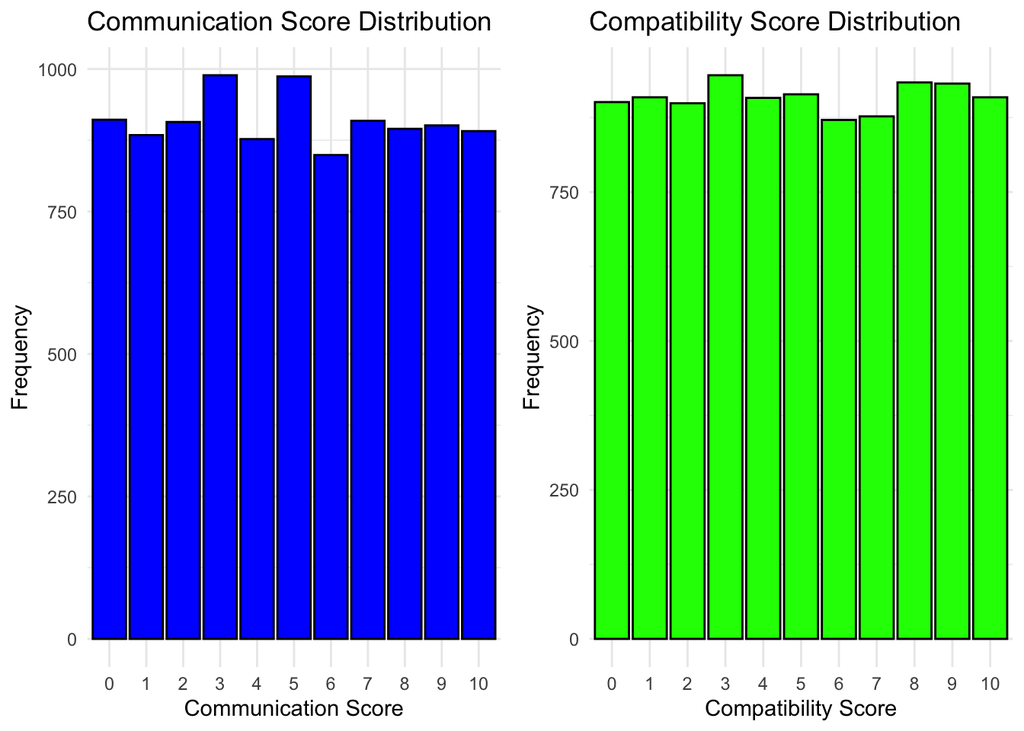

```r
# bar plot for Communication Score
p1 <- ggplot(proposal_df, aes(x = as.factor(CommunicationScore))) + geom_bar(fill = "blue", color = "black") + labs(title = "Communication Score Distribution", x = "Communication Score", y = "Frequency") + theme_minimal()

# bar plot for Compatibility Score
p2 <- ggplot(proposal_df, aes(x = as.factor(CompatibilityScore))) + geom_bar(fill = "green", color = "black") + labs(title = "Compatibility Score Distribution", x = "Compatibility Score", y = "Frequency") + theme_minimal()

grid.arrange(p1, p2, ncol = 2)
```

## STEP 4: SMART Questions

### 4.1: Is there a statistically significant difference in the Response variable (Proposal Accepted vs Rejected) based on the Income of the individual?

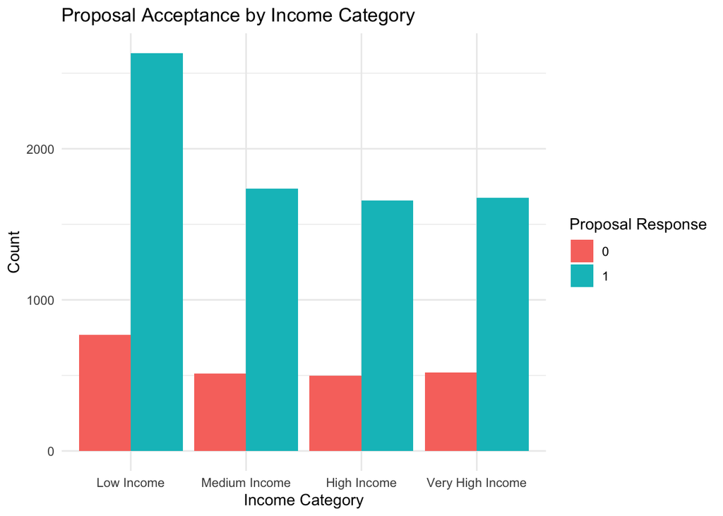

```r
ggplot(proposal_df, aes(x = cut(Income, breaks = c(5000, 20000, 30000, 40000, 50000), labels = c("Low Income", "Medium Income", "High Income", "Very High Income"), include.lowest = TRUE), fill = factor(Response))) + geom_bar(position = "dodge") + labs(title = "Proposal Acceptance by Income Category", x = "Income Category", y = "Count", fill = "Proposal Response") + theme_minimal()
```

Null Hypothesis: There is no statistically significant difference in the Proposal Response based on an Individual’s Income. Alternative Hypothesis: There is a statistically significant difference in the Proposal Response based on an Individual’s Income.

```r
# Contingency table for Income Category and Proposal Response
contingency_table <- table(cut(proposal_df$Income,
                               breaks = c(5000, 20000, 30000, 40000, 50000),
                               labels = c("Low Income", "Medium Income", "High Income", "Very High Income"),
                               include.lowest = TRUE),
                           proposal_df$Response)

# Chi-Square Test
chi_square_test <- chisq.test(contingency_table)
chi_square_test
```

```
##
##  Pearson's Chi-squared test
##
## data:  contingency_table
## X-squared = 1, df = 3, p-value = 0.8
```

The P-value is greater than significance level(0.05). Therefore, we cannot reject the Null Hypothesis. There is no statistically significant difference in the Proposal Response based on an Individual’s Income.

### 4.2: Can a linear regression model effectively predict the Income of an individual using Age, Height, and RomanticGestureScore as predictors?

```r
# linear regression model
model_lr <- lm(Income ~ Age + Height + RomanticGestureScore, data = proposal_df)

# Summary of the model
summary(model_lr)
```

```
##
## Call:
## lm(formula = Income ~ Age + Height + RomanticGestureScore, data = proposal_df)
##
## Residuals:
##    Min     1Q Median     3Q    Max
## -22896 -11196   -123  11147  23236
##
## Coefficients:
##                        Estimate Std. Error t value Pr(>|t|)
## (Intercept)            26243.72    1368.27   19.18   <2e-16 ***
## Age                        2.83       6.17    0.46    0.646
## Height                     2.15       7.40    0.29    0.771
## RomanticGestureScore1    974.93     604.61    1.61    0.107
## RomanticGestureScore2    112.23     620.65    0.18    0.857
## RomanticGestureScore3    643.40     609.54    1.06    0.291
## RomanticGestureScore4     96.88     610.47    0.16    0.874
## RomanticGestureScore5    745.12     603.69    1.23    0.217
## RomanticGestureScore6   1070.81     607.35    1.76    0.078 .
## RomanticGestureScore7    507.60     615.26    0.83    0.409
## RomanticGestureScore8    -35.71     608.28   -0.06    0.953
## RomanticGestureScore9    734.83     616.67    1.19    0.233
## RomanticGestureScore10   516.61     603.60    0.86    0.392
## ---
## Signif. codes:  0 '***' 0.001 '**' 0.01 '*' 0.05 '.' 0.1 ' ' 1
##
## Residual standard error: 13000 on 9987 degrees of freedom
## Multiple R-squared:  0.000851,   Adjusted R-squared:  -0.000349
## F-statistic: 0.709 on 12 and 9987 DF,  p-value: 0.744
```

```r
# R-squared value
rsq <- summary(model_lr)$r.squared
cat("R-squared:", rsq, "\n")
```

```
## R-squared: 0.000851
```

```r
# Mean Squared Error (MSE)
mse <- mean(residuals(model_lr)^2)
cat("Mean Squared Error:", mse, "\n")
```

```
## Mean Squared Error: 1.7e+08
```

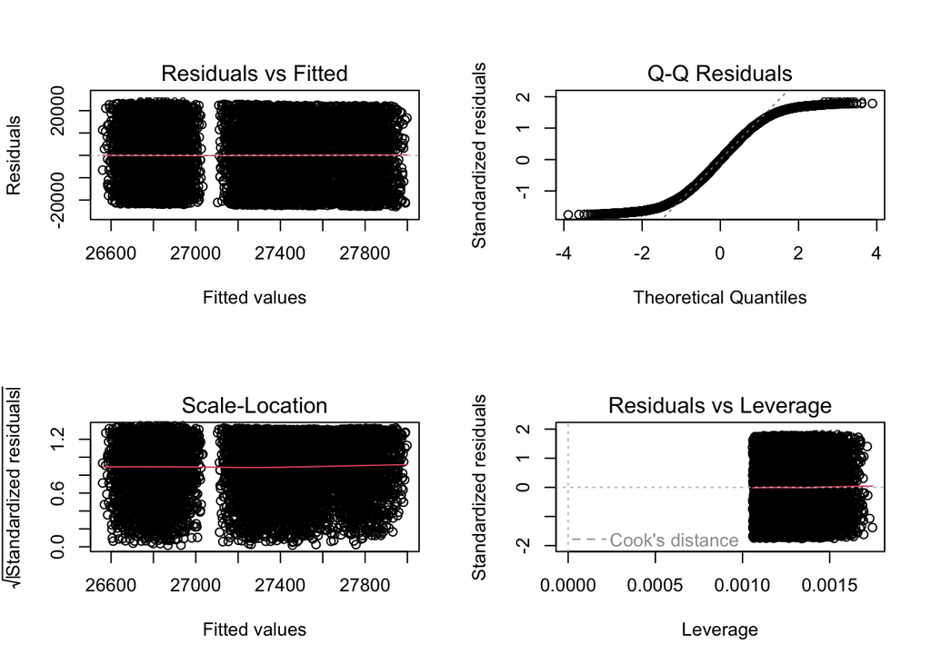

```r
# Plot diagnostic plots
par(mfrow = c(2, 2))
plot(model_lr)
```

We will now try to predict income of an individual who are 30 years old and 160 cm tall with a score of 8 for Romantic Gesture.

```r
# Sample input data
input1 <- data.frame(Age = 30, Height = 160, RomanticGestureScore = factor(8, levels = levels(proposal_df$RomanticGestureScore)))

#Prediction
predict1 <- predict(model_lr, newdata = input1)
predict1
```

```
##     1
## 26637
```

The Linear Regression Model has predicted the income of such individual mentioned above to be $26637.

#### Logistic Regression Model

```r
# Split the dataset into training and testing sets
set.seed(123)
index <- createDataPartition(proposal_df$Response, p = 0.8, list = FALSE)
train_data <- proposal_df[index, ]
test_data <- proposal_df[-index, ]

# Logistic Regression Model
logistic_model <- glm(Response ~ RomanticGestureScore + CompatibilityScore + CommunicationScore, data = train_data, family = binomial)
logistic_probabilities <- predict(logistic_model, test_data, type = "response")
logistic_predicted <- ifelse(logistic_probabilities > 0.5, 1, 0)
actual <- as.factor(test_data$Response)
predicted <- as.factor(logistic_predicted)

# Confusion Matrix and metrics
confusion <- confusionMatrix(predicted, actual, positive = "1")
accuracy <- confusion$overall["Accuracy"]
precision <- confusion$byClass["Pos Pred Value"]
recall <- confusion$byClass["Sensitivity"]
f1_score <- 2 * (precision * recall) / (precision + recall)
# AUC
roc_curve <- roc(actual, logistic_probabilities, levels = c("0", "1"))
auc_value <- auc(roc_curve)

# Print metrics
cat("Logistic Regression Performance Metrics:\n")
```

```
## Logistic Regression Performance Metrics:
```

```r
cat("Accuracy: ", accuracy, "\n")
```

```
## Accuracy:  0.795
```

```r
cat("Precision: ", precision, "\n")
```

```
## Precision:  0.834
```

```r
cat("Recall: ", recall, "\n")
```

```
## Recall:  0.917
```

```r
cat("F1-Score: ", f1_score, "\n")
```

```
## F1-Score:  0.873
```

```r
cat("AUC: ", auc_value, "\n")
```

```
## AUC:  0.815
```

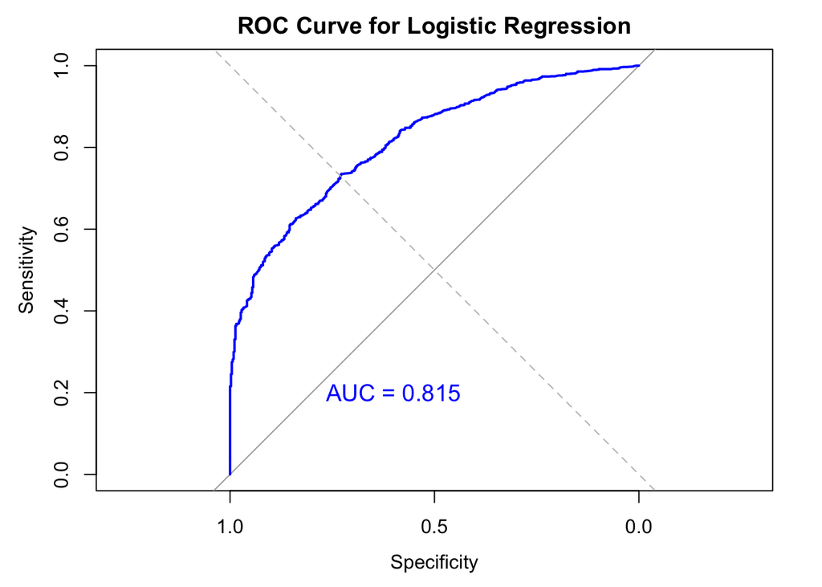

```r
# Plot ROC Curve
plot(roc_curve, main = "ROC Curve for Logistic Regression", col = "blue", lwd = 2)
abline(a = 0, b = 1, col = "gray", lty = 2)
auc_text <- paste("AUC =", round(auc_value, 3)) # Add AUC value to the plot
text(0.6, 0.2, auc_text, col = "blue", cex = 1.2)
```

#### Desicion Tree Model

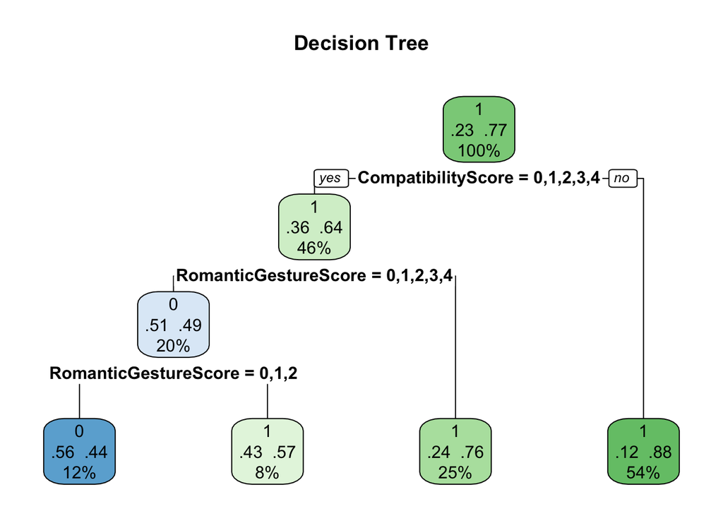

```r
# Split the dataset into training and testing sets
set.seed(123)
trainIndex <- createDataPartition(proposal_df$Response, p = 0.8, list = FALSE)
trainData <- proposal_df[trainIndex, ]
testData <- proposal_df[-trainIndex, ]

# Decision Tree Model
decision_tree_model <- rpart(Response ~ RomanticGestureScore + CompatibilityScore + CommunicationScore, data = trainData, method = "class")
predicted_probabilities_tree <- predict(decision_tree_model, proposal_df, type = "prob")[, 2]
predicted_classes_tree <- predict(decision_tree_model, proposal_df, type = "class")
actual <- as.factor(proposal_df$Response)

# Visualize the Decision Tree
rpart.plot(decision_tree_model, type = 2, extra = 104, main = "Decision Tree")
```

```r
# Confusion Matrix and metrics
confusion_tree <- confusionMatrix(as.factor(predicted_classes_tree), actual, positive = "1")
accuracy_tree <- confusion_tree$overall["Accuracy"]
precision_tree <- confusion_tree$byClass["Pos Pred Value"]
recall_tree <- confusion_tree$byClass["Sensitivity"]
f1_score_tree <- 2 * (precision_tree * recall_tree) / (precision_tree + recall_tree)
roc_curve_tree <- roc(actual, predicted_probabilities_tree, levels = c("0", "1"))
auc_value_tree <- auc(roc_curve_tree)

# Print Metrics
cat("Decision Tree Metrics:\n")
```

```
## Decision Tree Metrics:
```

```r
cat("Accuracy:", round(accuracy_tree, 3), "\n")
```

```
## Accuracy: 0.786
```

```r
cat("Precision:", round(precision_tree, 3), "\n")
```

```
## Precision: 0.818
```

```r
cat("Recall:", round(recall_tree, 3), "\n")
```

```
## Recall: 0.93
```

```r
cat("F1-Score:", round(f1_score_tree, 3), "\n")
```

```
## F1-Score: 0.87
```

```r
cat("AUC:", round(auc_value_tree, 3), "\n")
```

```
## AUC: 0.717
```

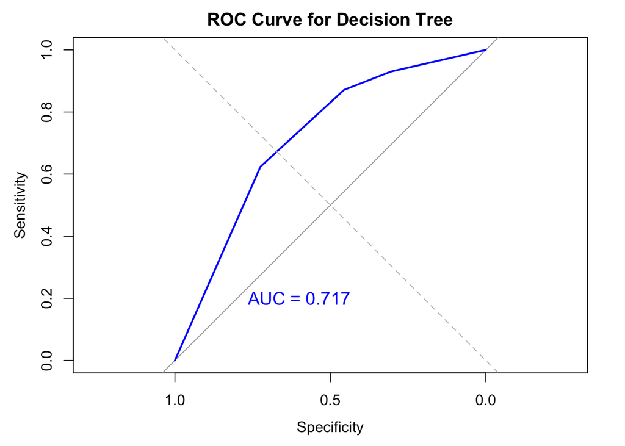

```r
# Plot ROC Curve
plot(roc_curve_tree, main = "ROC Curve for Decision Tree", col = "blue", lwd = 2)
abline(a = 0, b = 1, col = "gray", lty = 2)
auc_text_tree <- paste("AUC =", round(auc_value_tree, 3)) # Add AUC value to the plot
text(0.6, 0.2, auc_text_tree, col = "blue", cex = 1.2)
```

#### Random Forest Model

```
## Random Forest Metrics:
```

```
## Accuracy: 0.807
```

```
## Precision: 0.841
```

```
## Recall: 0.924
```

```
## F1-Score: 0.88
```

```
## AUC: 0.846
```

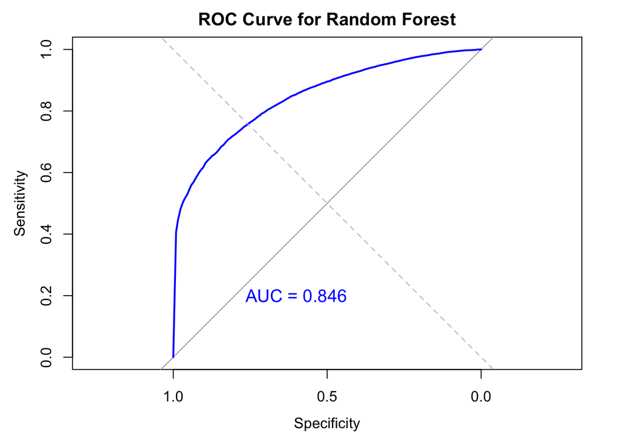

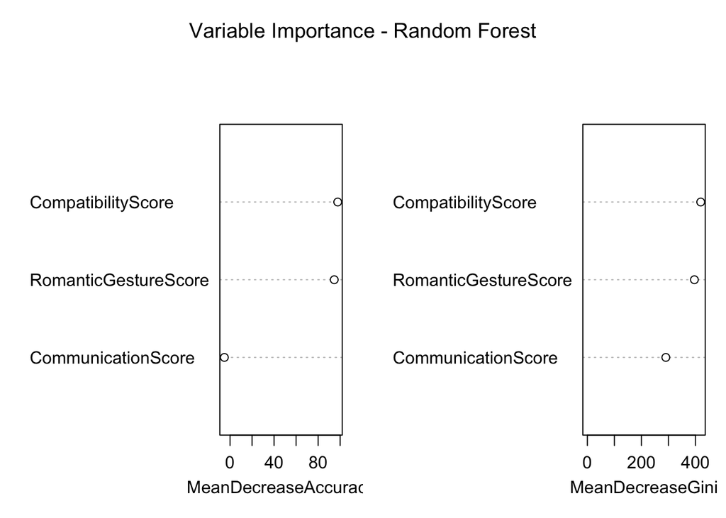

### 4.4: How can we enhance the accuracy of a Random Forest model in predicting proposal acceptance using features like Income, Age, and DistanceKM? Adding what other features might further improve the model’s performance, and how would the model’s accuracy change as a result?

```r
# Split the dataset into training and testing sets

set.seed(123)
trainIndex <- createDataPartition(proposal_df$Response, p = 0.8, list = FALSE)
trainData <- proposal_df[trainIndex, ]
testData <- proposal_df[-trainIndex, ]

# Random Forest Model
random_forest_model <- randomForest(Response ~ Height + Income + Age + DistanceKM, data = trainData, ntree = 500, mtry = 2, importance = TRUE)
print(random_forest_model)
```

```
##
## Call:
##  randomForest(formula = Response ~ Height + Income + Age + DistanceKM,      data = trainData, ntree = 500, mtry = 2, importance = TRUE)
##                Type of random forest: classification
##                      Number of trees: 500
## No. of variables tried at each split: 2
##
##         OOB estimate of  error rate: 24.1%
## Confusion matrix:
##     0    1 class.error
## 0  47 1793      0.9745
## 1 136 6024      0.0221
```

```r
predicted_probabilities_rf <- predict(random_forest_model, proposal_df, type = "prob")[, 2]  # Probabilities for class 1
predicted_classes_rf <- predict(random_forest_model, proposal_df, type = "response")# Predicted classes
actual <- as.factor(proposal_df$Response)

# Confusion Matrix and metrics
confusion_rf <- confusionMatrix(as.factor(predicted_classes_rf), actual, positive = "1")
accuracy_rf <- confusion_rf$overall["Accuracy"]
precision_rf <- confusion_rf$byClass["Pos Pred Value"]
recall_rf <- confusion_rf$byClass["Sensitivity"]
f1_score_rf <- 2 * (precision_rf * recall_rf) / (precision_rf + recall_rf)
roc_curve_rf <- roc(actual, predicted_probabilities_rf, levels = c("0", "1"))
auc_value_rf <- auc(roc_curve_rf)


# Print Metrics
cat("Random Forest Metrics:\n")
```

```
## Random Forest Metrics:
```

```r
cat("Accuracy:", round(accuracy_rf, 3), "\n")
```

```
## Accuracy: 0.951
```

```r
cat("Precision:", round(precision_rf, 3), "\n")
```

```
## Precision: 0.944
```

```r
cat("Recall:", round(recall_rf, 3), "\n")
```

```
## Recall: 0.995
```

```r
cat("F1-Score:", round(f1_score_rf, 3), "\n")
```

```
## F1-Score: 0.969
```

```r
cat("AUC:", round(auc_value_rf, 3), "\n")
```

```
## AUC: 0.97
```

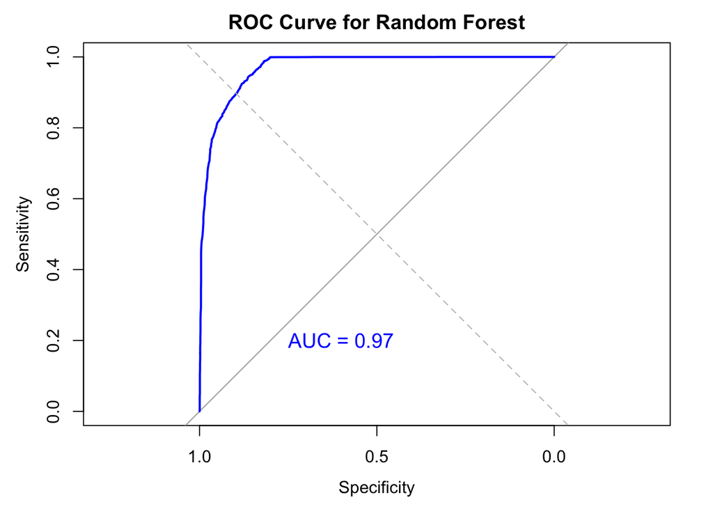

```r
# Plot ROC Curve
plot(roc_curve_rf, main = "ROC Curve for Random Forest", col = "blue", lwd = 2)
abline(a = 0, b = 1, col = "gray", lty = 2)
auc_text_rf <- paste("AUC =", round(auc_value_rf, 3)) # Add AUC value to the plot
text(0.6, 0.2, auc_text_rf, col = "blue", cex = 1.2)
```

We consider all variables here to obtain the Mean Decrease Gini Scores of each variable

```r
# Train a random forest model for comparision
rf_model <- randomForest(Response ~ ., data = proposal_df)

# View feature importance
importance(rf_model)
```

```
##                      MeanDecreaseGini
## Height                          436.6
## Age                             434.8
## Income                          522.8
## RomanticGestureScore            553.7
## CompatibilityScore              602.5
## CommunicationScore              374.9
## DistanceKM                      466.9
## AgeCategory                      82.3
```

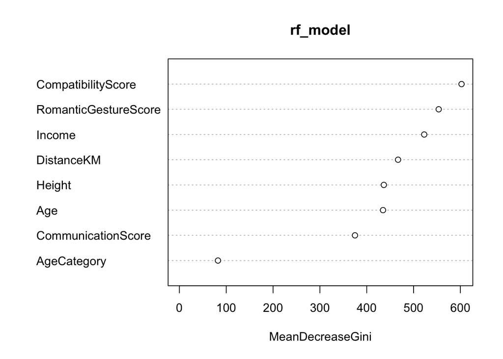

```r
varImpPlot(rf_model) # Plot
```

The Final Random Forest Model

```r
# Updated Model

set.seed(123)
trainIndex <- createDataPartition(proposal_df$Response, p = 0.8, list = FALSE)
trainData <- proposal_df[trainIndex, ]
testData <- proposal_df[-trainIndex, ]

# Random Forest Model
random_forest_model <- randomForest(Response ~ Height + Income + Age + DistanceKM + CompatibilityScore + RomanticGestureScore, data = trainData, ntree = 500, mtry = 2, importance = TRUE)
print(random_forest_model)
```

```
##
## Call:
##  randomForest(formula = Response ~ Height + Income + Age + DistanceKM +      CompatibilityScore + RomanticGestureScore, data = trainData,      ntree = 500, mtry = 2, importance = TRUE)
##                Type of random forest: classification
##                      Number of trees: 500
## No. of variables tried at each split: 2
##
##         OOB estimate of  error rate: 22.5%
## Confusion matrix:
##     0    1 class.error
## 0 471 1369      0.7440
## 1 429 5731      0.0696
```

```r
predicted_probabilities_rf <- predict(random_forest_model, proposal_df, type = "prob")[, 2]
predicted_classes_rf <- predict(random_forest_model, proposal_df, type = "response")
actual <- as.factor(proposal_df$Response)

# Confusion Matrix and metrics
confusion_rf <- confusionMatrix(as.factor(predicted_classes_rf), actual, positive = "1")
accuracy_rf <- confusion_rf$overall["Accuracy"]
precision_rf <- confusion_rf$byClass["Pos Pred Value"]
recall_rf <- confusion_rf$byClass["Sensitivity"]
f1_score_rf <- 2 * (precision_rf * recall_rf) / (precision_rf + recall_rf)
roc_curve_rf <- roc(actual, predicted_probabilities_rf, levels = c("0", "1"))
auc_value_rf <- auc(roc_curve_rf)

# Print Metrics
cat("Random Forest Metrics:\n")
```

```
## Random Forest Metrics:
```

```r
cat("Accuracy:", round(accuracy_rf, 3), "\n")
```

```
## Accuracy: 0.959
```

```r
cat("Precision:", round(precision_rf, 3), "\n")
```

```
## Precision: 0.959
```

```r
cat("Recall:", round(recall_rf, 3), "\n")
```

```
## Recall: 0.989
```

```r
cat("F1-Score:", round(f1_score_rf, 3), "\n")
```

```
## F1-Score: 0.974
```

```r
cat("AUC:", round(auc_value_rf, 3), "\n")
```

```
## AUC: 0.984
```

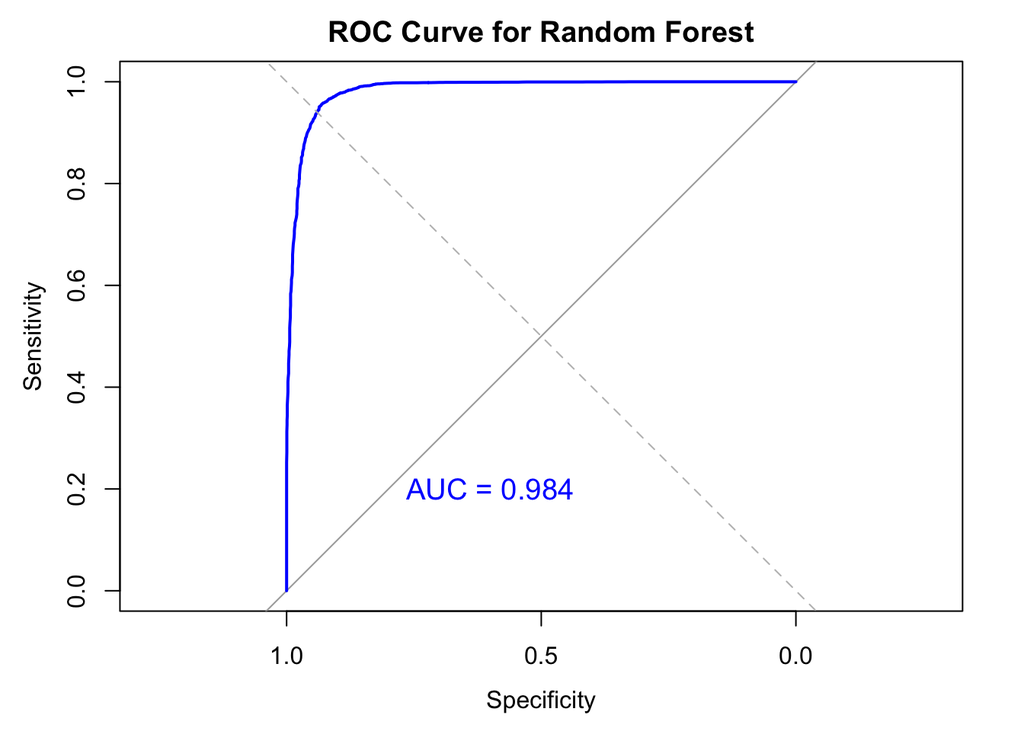

```r
# Plot ROC Curve
plot(roc_curve_rf, main = "ROC Curve for Random Forest", col = "blue", lwd = 2)
abline(a = 0, b = 1, col = "gray", lty = 2)
auc_text_rf <- paste("AUC =", round(auc_value_rf, 3))
text(0.6, 0.2, auc_text_rf, col = "blue", cex = 1.2)
```

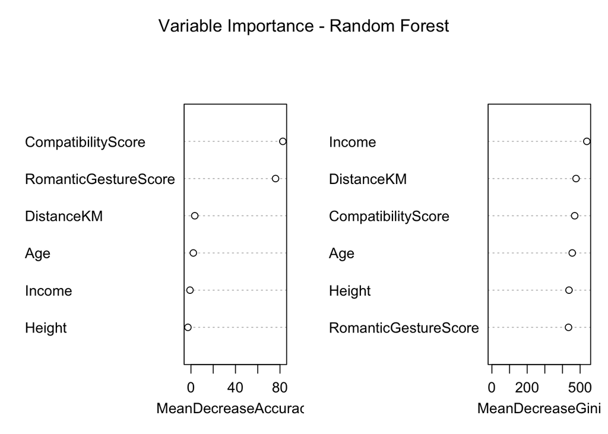

```r
# Variable Importance Plot
varImpPlot(random_forest_model, main = "Variable Importance - Random Forest")
```

Let’s consider an example and try to predict the Response for given values.

```r
# Prediction model
subject <- data.frame(
  RomanticGestureScore = factor(10, levels = levels(proposal_df$RomanticGestureScore)), CompatibilityScore = factor(7, levels = levels(proposal_df$CompatibilityScore)), DistanceKM = 10, Height = 169, Income = 6000, Age = 23)

predicted_classes <- predict(random_forest_model, subject, type = "response")

predicted_probabilities <- predict(random_forest_model, subject, type = "prob")

cat("Predicted Class (0 or 1):\n")
```

```
## Predicted Class (0 or 1):
```

```r
print(predicted_classes)
```

```
## 1
## 1
## Levels: 0 1
```

The Model Predicts the outcome to be ‘Yes’(1).